# Stat 480 - Homework #3

Zahra Khoshmanesh

2/6/2020

## Spotify data

1. Download the RMarkdown file with these homework instructions to use as a template for your work. Make sure to replace “Your Name” in the YAML with your name.
2. Using the command below, read in the spotify data set into your R session.

```r
spotify <- read.csv("https://raw.githubusercontent.com/Stat480-at-ISU/Stat480-at-ISU.github.io/master/homework/data/spotify.csv")
```

3. Use one of our object inspecting functions and interpret the result in the data that you see.
4. Use the package `ggplot2` to draw a barchart of the genres. In addition, map the genre categories to the fill color of the barchart.
5. Use the package `ggplot2` to draw a histogram of one of the continuous variables in the dataset. Use fill color to show the genre categories and adjust the binwidth if necessary. Use `facet_wrap()` to create a histogram for each of the genre categories.
6. Use the package `ggplot2` to draw a boxplot to compare one of the continuous variables with the genre categories. Again, use fill color to show the genre categories.
7. For each of the three figures above, write a two-three sentence summary, describing the
   1. **structure of the plot**: what type of plot is it? Which variables are mapped to x, to y, and to the (fill) color?
   2. **main message of the plot**: what is your main finding, i.e. what do you want viewers to learn from the plot?
   3. **additional message**: point out anomalies or outliers, if there are any.

Due date: the homework is due before class on Thursday.

For the submission: submit your solution in an R Markdown file and (just for insurance) submit the corresponding html file with it.

## Solution

read data

1. Download the RMarkdown file with these homework instructions to use as a template for your work. Make sure to replace “Your Name” in the YAML with your name.
2. Using the command below, read in the spotify data set into your R session.

```r
spotify <- read.csv("https://raw.githubusercontent.com/Stat480-at-ISU/Stat480-at-ISU.github.io/master/homework/data/spotify.csv")
```

3. Use one of our object inspecting functions and interpret the result in the data that you see.

We use summary to know the min,max,median,mean,1st quantile and 3rd quantile of each continous variables and frequencies for categoricals variables in spotify data.From summary we can see that Queen has the highest frequent artist in the data. popularity of each record can be between 0 to 100 with average of 42.78 in the data set.the highest frequent genre is edm following rap.

```r
#use summary to know the min,max,median,mean,1st quantile and 3rd quantile of each variables in spotify data
summary(spotify)
```

```
##                     track_artist  track_popularity playlist_genre
##  Queen                    :  39   Min.   :  0.00   edm  :1817
##  David Guetta             :  35   1st Qu.: 25.00   latin:1535
##  Don Omar                 :  33   Median : 46.00   pop  :1660
##  The Chainsmokers         :  33   Mean   : 42.78   r&b  :1636
##  Dimitri Vegas & Like Mike:  32   3rd Qu.: 62.00   rap  :1791
##  (Other)                  :9826   Max.   :100.00   rock :1561
##  NA's                     :   2
##                  playlist_subgenre     release_date   duration_min
##  progressive electro house: 536    2020-01-10:  78   Min.   :0.4915
##  indie poptimism          : 510    2012-01-01:  73   1st Qu.:3.1287
##  southern hip hop         : 499    2019-11-15:  68   Median :3.6084
##  latin hip hop            : 494    2019-11-22:  68   Mean   :3.7693
##  neo soul                 : 475    2013-01-01:  67   3rd Qu.:4.2264
##  hard rock                : 474    (Other)   :9065   Max.   :8.6302
##  (Other)                  :7012    NA's      : 581
##   danceability        energy          loudness        speechiness
##  Min.   :0.0771   Min.   :0.0118   Min.   :-46.448   Min.   :0.0228
##  1st Qu.:0.5600   1st Qu.:0.5770   1st Qu.: -8.213   1st Qu.:0.0410
##  Median :0.6720   Median :0.7210   Median : -6.162   Median :0.0623
##  Mean   :0.6543   Mean   :0.6971   Mean   : -6.746   Mean   :0.1074
##  3rd Qu.:0.7630   3rd Qu.:0.8390   3rd Qu.: -4.654   3rd Qu.:0.1330
##  Max.   :0.9830   Max.   :1.0000   Max.   :  0.551   Max.   :0.8690
##
##   acousticness          liveness          tempo
##  Min.   :0.0000023   Min.   :0.0131   Min.   : 35.48
##  1st Qu.:0.0150000   1st Qu.:0.0931   1st Qu.: 99.97
##  Median :0.0810000   Median :0.1280   Median :122.02
##  Mean   :0.1763094   Mean   :0.1894   Mean   :121.13
##  3rd Qu.:0.2520000   3rd Qu.:0.2480   3rd Qu.:135.00
##  Max.   :0.9790000   Max.   :0.9960   Max.   :214.52
##
```

```r
#let us check the structure of the data
str(spotify)
```

```
## 'data.frame':    10000 obs. of  13 variables:
##  $ track_artist     : Factor w/ 5041 levels "'Til Tuesday",..: 3982 398 231 1581 4574 377 3210 3770 3377 2449 ...
##  $ track_popularity : int  30 20 2 44 54 67 54 58 13 56 ...
##  $ playlist_genre   : Factor w/ 6 levels "edm","latin",..: 6 3 3 5 6 5 2 1 5 2 ...
##  $ playlist_subgenre: Factor w/ 24 levels "album rock","big room",..: 8 11 11 9 8 9 20 5 7 12 ...
##  $ release_date     : Factor w/ 2679 levels "1957-01-01","1963-05-27",..: 2587 1815 1724 2507 814 2561 2170 2465 1615 2298 ...
##  $ duration_min     : num  1.92 5.27 4.44 3.49 3.16 ...
##  $ danceability     : num  0.297 0.546 0.589 0.74 0.451 0.652 0.701 0.698 0.625 0.863 ...
##  $ energy           : num  0.974 0.591 0.846 0.721 0.884 0.862 0.772 0.895 0.805 0.627 ...
##  $ loudness         : num  -4.1 -5.65 -5.46 -6.32 -3.45 ...
##  $ speechiness      : num  0.135 0.0284 0.0377 0.177 0.0335 0.206 0.184 0.101 0.388 0.206 ...
##  $ acousticness     : num  0.00366 0.0616 0.069 0.762 0.00177 0.161 0.0515 0.00764 0.552 0.0485 ...
##  $ liveness         : num  0.113 0.275 0.0904 0.0922 0.193 0.203 0.0959 0.217 0.108 0.0968 ...
##  $ tempo            : num  131.3 120 122 120 97.5 ...
```

```r
#print first 6 rows of data
head(spotify)
```

```
##       track_artist track_popularity playlist_genre playlist_subgenre
## 1      Scooped Up!               30           rock         hard rock
## 2     Bad Feelings               20            pop   indie poptimism
## 3      Andrew Ripp                2            pop   indie poptimism
## 4      Fotty Seven               44            rap           hip hop
## 5 Three Days Grace               54           rock         hard rock
## 6     Baani Sandhu               67            rap           hip hop
##   release_date duration_min danceability energy loudness speechiness
## 1   2019-10-10     1.916667        0.297  0.974   -4.096      0.1350
## 2   2016-05-25     5.266667        0.546  0.591   -5.649      0.0284
## 3   2015-10-16     4.436217        0.589  0.846   -5.455      0.0377
## 4   2019-07-12     3.491783        0.740  0.721   -6.323      0.1770
## 5   2006-06-25     3.155117        0.451  0.884   -3.451      0.0335
## 6   2019-09-12     3.500000        0.652  0.862   -2.290      0.2060
##   acousticness liveness   tempo
## 1      0.00366   0.1130 131.333
## 2      0.06160   0.2750 120.031
## 3      0.06900   0.0904 122.000
## 4      0.76200   0.0922 119.956
## 5      0.00177   0.1930  97.480
## 6      0.16100   0.2030 173.859
```

The data is 10000 rows of music track having 13 features such as artist,popularity, subgenre ,…

4. Use the package `ggplot2` to draw a barchart of the genres. In addition, map the genre categories to the fill color of the barchart.

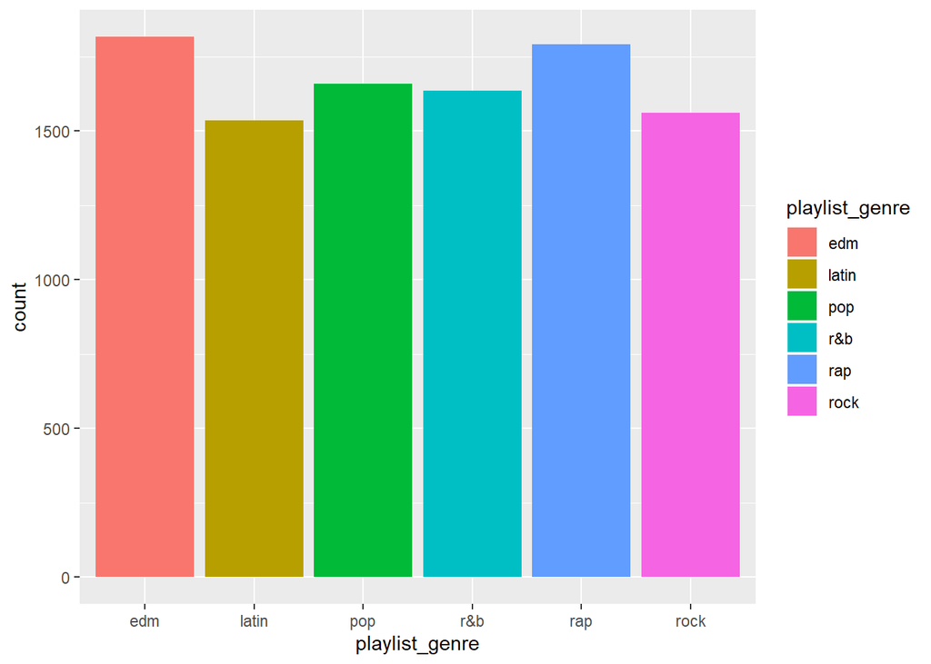

```r
library(ggplot2)

ggplot(data=spotify,aes(x=playlist_genre,fill=playlist_genre))+
  geom_bar()
```

**structure of the plot**: this is a barchart. barchart is used when we want to chart a univariate, here **genre**.So, x is **playlist_genre**. we do not have y here. fill is again **playlist_genre** since we want to use different categories in **genre** as map for our chart.

**main message of the plot**: In above barchart we can see the highest frequent of genre and order of different genre. here edm has the highest frequency in the data following rap,pop,r&b and latin. So, edm has the highest frequency. Also all different genre frequency are > 1500 in the data

**additional message**: we can not see any anamoly in barchart. need to use another chart like boxplot to detect outliers.

5. Use the package `ggplot2` to draw a histogram of one of the continuous variables in the dataset. Use fill color to show the genre categories and adjust the binwidth if necessary. Use `facet_wrap()` to create a histogram for each of the genre categories.

**structure of the plot**: this is histogram of popularity for different genre across the data. We selected popularity as x. since histogram is used to sow univariant continious variable, we do not have y. we use genre as filling color and used face_wrap to draw histogram for different categories of genre.

**additional message**: we can see huge number of zero popularity in all histograms and maybe indicating some anamolies.

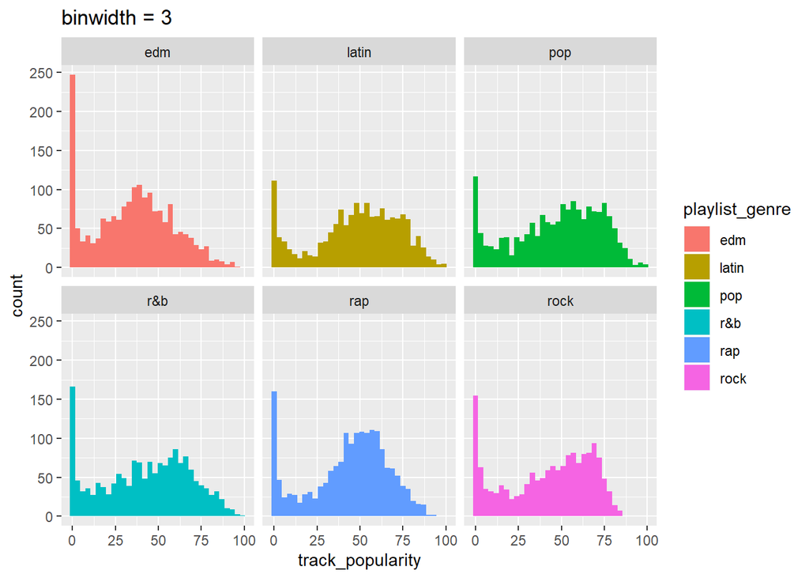

```r
ggplot(data = spotify,aes(x = track_popularity,fill=playlist_genre)) +
  geom_histogram(binwidth = 3) +
  facet_wrap(~playlist_genre) +
  ggtitle("binwidth = 3")
```

6. Use the package `ggplot2` to draw a boxplot to compare one of the continuous variables with the genre categories. Again, use fill color to show the genre categories.

**structure of the plot**: this is boxplot shows danceability for different genre across the data. We selected playlist_genre as x since want to show boxplot of different genre categories side by side. y is danceability. we use genre as filling color to map the chart .

**main message of the plot**: boxplot are used for group comparisons and outlier identifications.with boxplot we can compare median, 1quantile,3rd quantile,min and max. rock has the lowest median of dancability among all genre categories and rap has highest median. also we can see that edm,latin,pop and rock are symmetric (mean is close to median) if ignore the outliers.

**additional message**: we can see outliers in all different genre categories.latin has many outliers. rock has only a few outliers.

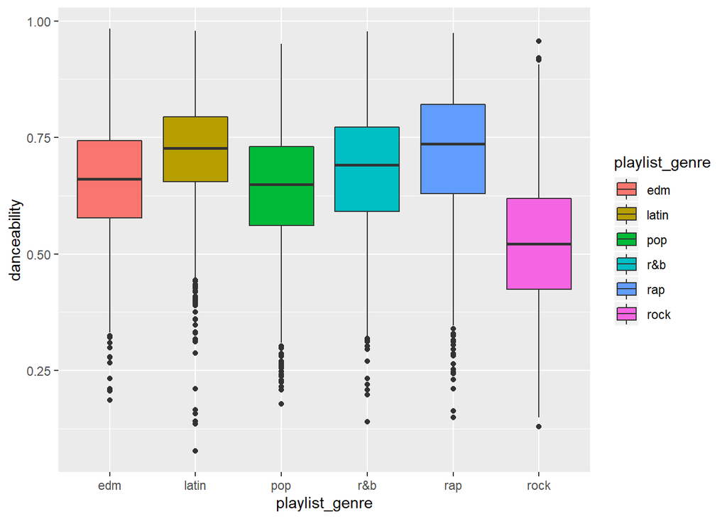

```r
ggplot(data=spotify)+
  geom_boxplot(aes(x =playlist_genre,y=danceability,fill=playlist_genre))
```